# Exploratory Abalone Analysis

Data Analysis Assignment #1 (50 points total)

McGovern, Kevin

February 10th, 2019

Abalones are a gastropod shellfish known for their unique and colorful inner shells. This observational study was conducted on 1036 abalone in order to collect data to be used for predicting the age of abalone. Determining the age of an abalone is traditionally done by counting the number of rings after drilling a hole in the shell. However, this can only be done after an abalone has been collected and the use of a microscope makes the process both time consuming and difficult.

The study chose to focus on many of the physical characteristics in abalone. Data captured included whole weight, shucked weight, height, diameter, length, as well as the classifications of sex, class, and rings. Additional descriptive variables were created to measure volume and the ratio of shucked weight to volume. Weight and volume were initially evaluated as potential targets for predicting age. However, even though there appeared to be a positive correlation, the data was too dispersed to draw any predictive power from either weight or volume. The challenge was further exacerbated by the fact that volume and weight have a vast range of values in adult abalone. It is inconclusive whether those variables actually hold predictive power due to issues with the age and sex classifications.

Determining the sex of an abalone is known to be a challenging process and some of that was shown in the results analyzed. This study captured instances where age classifications that should have been largely infants contained instances of male and female abalone and instances where older abalone (as determined by the number of rings) were classified as infants.

Additionally, the classes that were used to group abalone together by age were not uniform. There was an out-sized proportion of abalone that were classified in A3 (middle-aged abalone), leading to a potential skewing of the results that should be adjusted for if this data was going to be used effectively for building a predictive model. Some of the challenges with classes, rings, and sex make the conclusions difficult to trust. For example, observations of shuck and whole weight decreasing as some of the abalone aged may have been due to misclassification, not an actual causal link.

Overall, the study was deemed a failure and it was determined that additional data should be gathered. After doing this analysis, it is my recommendation that instead the researchers should collect this data again with more careful controls and more thoughtful classifications when measuring variables such as rings and sex.

```
## 'data.frame':    1036 obs. of  8 variables:
##  $ SEX   : Factor w/ 3 levels "F","I","M": 2 2 2 2 2 2 2 2 2 2 ...
##  $ LENGTH: num  5.57 3.67 10.08 4.09 6.93 ...
##  $ DIAM  : num  4.09 2.62 7.35 3.15 4.83 ...
##  $ HEIGHT: num  1.26 0.84 2.205 0.945 1.785 ...
##  $ WHOLE : num  11.5 3.5 79.38 4.69 21.19 ...
##  $ SHUCK : num  4.31 1.19 44 2.25 9.88 ...
##  $ RINGS : int  6 4 6 3 6 6 5 6 5 6 ...
##  $ CLASS : Factor w/ 5 levels "A1","A2","A3",..: 1 1 1 1 1 1 1 1 1 1 ...
```

(1)(a) (2 points) Use *summary()* to obtain and present descriptive statistics from mydata. Use table() to present a frequency table using CLASS and RINGS. There should be 115 cells in the table you present.

```
##  SEX         LENGTH           DIAM            HEIGHT
##  F:326   Min.   : 2.73   Min.   : 1.995   Min.   :0.525
##  I:329   1st Qu.: 9.45   1st Qu.: 7.350   1st Qu.:2.415
##  M:381   Median :11.45   Median : 8.925   Median :2.940
##          Mean   :11.08   Mean   : 8.622   Mean   :2.947
##          3rd Qu.:13.02   3rd Qu.:10.185   3rd Qu.:3.570
##          Max.   :16.80   Max.   :13.230   Max.   :4.935
##      WHOLE             SHUCK              RINGS        CLASS
##  Min.   :  1.625   Min.   :  0.5625   Min.   : 3.000   A1:108
##  1st Qu.: 56.484   1st Qu.: 23.3006   1st Qu.: 8.000   A2:236
##  Median :101.344   Median : 42.5700   Median : 9.000   A3:329
##  Mean   :105.832   Mean   : 45.4396   Mean   : 9.993   A4:188
##  3rd Qu.:150.319   3rd Qu.: 64.2897   3rd Qu.:11.000   A5:175
##  Max.   :315.750   Max.   :157.0800   Max.   :25.000
##      VOLUME            RATIO
##  Min.   :  3.612   Min.   :0.06734
##  1st Qu.:163.545   1st Qu.:0.12241
##  Median :307.363   Median :0.13914
##  Mean   :326.804   Mean   :0.14205
##  3rd Qu.:463.264   3rd Qu.:0.15911
##  Max.   :995.673   Max.   :0.31176
```

```
##
##        3   4   5   6   7   8   9  10  11  12  13  14  15  16  17  18  19
##   A1   9   8  24  67   0   0   0   0   0   0   0   0   0   0   0   0   0
##   A2   0   0   0   0  91 145   0   0   0   0   0   0   0   0   0   0   0
##   A3   0   0   0   0   0   0 182 147   0   0   0   0   0   0   0   0   0
##   A4   0   0   0   0   0   0   0   0 125  63   0   0   0   0   0   0   0
##   A5   0   0   0   0   0   0   0   0   0   0  48  35  27  15  13   8   8
##
##       20  21  22  23  24  25
##   A1   0   0   0   0   0   0
##   A2   0   0   0   0   0   0
##   A3   0   0   0   0   0   0
##   A4   0   0   0   0   0   0
##   A5   6   4   1   7   2   1
```

**Question (1 point): Briefly discuss the variable types and distributional implications such as potential skewness and outliers.**

*Answer: The variable sex is a categorical variable containing male, female, and infant (due to difficulties in determining sex in young abalone). There are 55 more males than females, which could skew some of the results later to overrepresent male abalone. Length and diameter appear to be roughly normally distributed because the mean and median are near equal but it looks like the left tail contains one or more an outliers due to the low minimums (we will have to see in further analysis). Whole weight and volume look to be normally distributed based on these statistics as well but the range is much larger and the mean is only marginally higher than the median. Shuck appears to have a near-normal interquartile range but with such a large maximum value, it is possible that there are outliers on the right tail. Rings is an integer and because it is a rough estimation of age, the expectation should be for a uniform distribution to make sure that all ages are represented equally. However, the summary statistics do not show that. Instead rings appears to be right skewed, with a mean almost 1 full ring above the median. The class variable is another categorical variable (calculated by grouping rings together) that is a representation of rings and age. As you can see from the summary, there are a high proportion of A3 abalones. Ratio was a variable we calculated by taking shuck and dividing by volume. Because the two variables used to calculate the value are near normal, this ratio appears close to normal as well.*

(1)(b) (1 point) Generate a table of counts using SEX and CLASS. Add margins to this table (Hint: There should be 15 cells in this table plus the marginal totals. Apply *table()* first, then pass the table object to *addmargins()* (Kabacoff Section 7.2 pages 144-147)). Lastly, present a barplot of these data; ignoring the marginal totals.

```
##
##         A1   A2   A3   A4   A5  Sum
##   F      5   41  121   82   77  326
##   I     91  133   65   21   19  329
##   M     12   62  143   85   79  381
##   Sum  108  236  329  188  175 1036
```

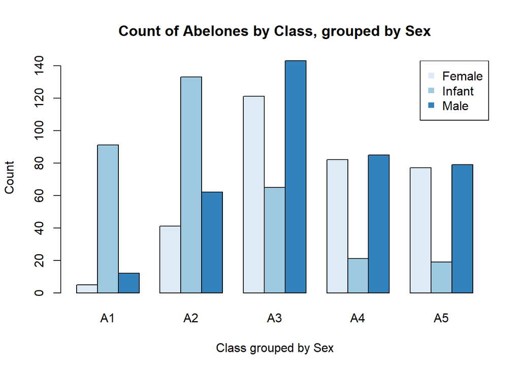

**Question (2 points): Discuss the sex distribution of abalones. What stands out about the distribution of abalones by CLASS?**

*Answer: The class variable is a codification of ages based on rings, with A1 being the youngest, A5 the oldest. Some things stand out about the distribution of this variable. The first observation is that because A1 is the youngest class of abalone, the expectation is that all abalone are classified as infant and there wouldn’t be any male or female abalone in this class. One possible explanation is that some infants were classified as male or female if sex could be determined but ideally the class would be categorized consistently. Additionally, the expectation is that all of the infant abalone should be captured in either class A1 or A2 but there are 65 infants in A3 and around 21 and 19 infants in the A4 and A5 classes, respectively. It seems as though there were additional difficulties determining sex in older abalone and those were all grouped in the infant sex. The last thing seen from this distribution is that in the A2 and A3 classes there is a much higher proportion of males than females. This indicates that there is a possibility that the sample was not random, determining sex is easier for male abalone, or that male abalone are more represented in the population than females. The data alone makes it difficult to draw a conclusion.*

(1)(c) (1 point) Select a simple random sample of 200 observations from “mydata” and identify this sample as “work.” Use *set.seed(123)* prior to drawing this sample. Do not change the number 123. Note that *sample()* “takes a sample of the specified size from the elements of x.” We cannot sample directly from “mydata.” Instead, we need to sample from the integers, 1 to 1036, representing the rows of “mydata.” Then, select those rows from the data frame (Kabacoff Section 4.10.5 page 87).

Using “work”, construct a scatterplot matrix of variables 2-6 with *plot(work[, 2:6])* (these are the continuous variables excluding VOLUME and RATIO). The sample “work” will not be used in the remainder of the assignment.

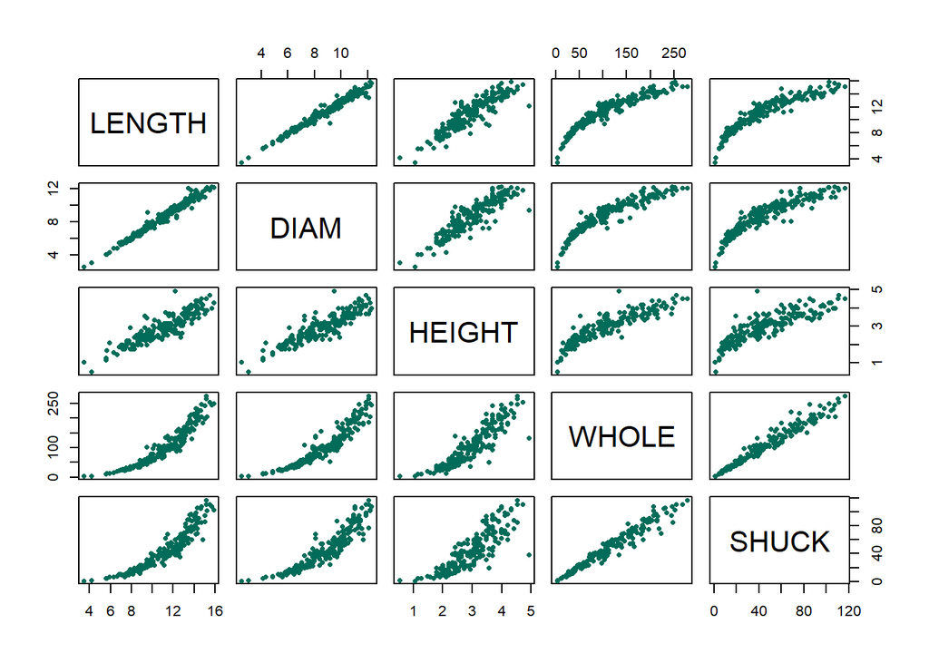

(2)(a) (1 point) Use “mydata” to plot WHOLE versus VOLUME. Color code data points by CLASS.

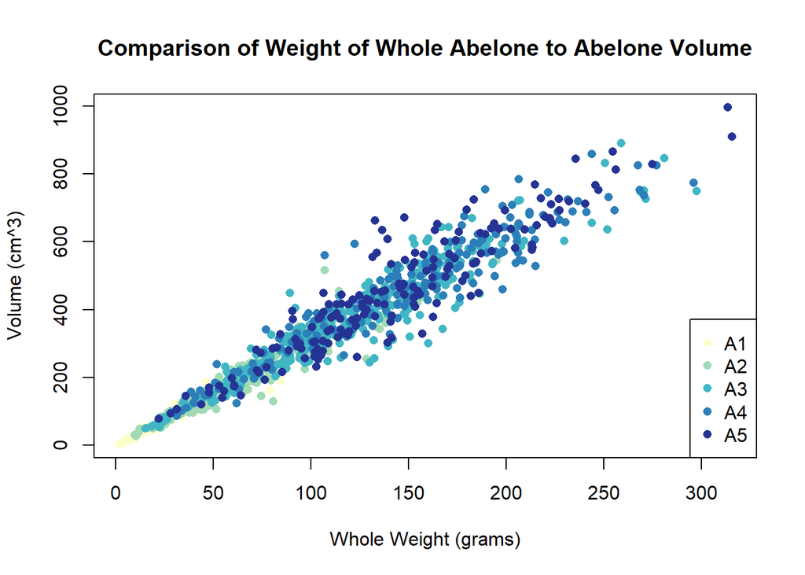

(2)(b) (2 points) Use “mydata” to plot SHUCK versus WHOLE with WHOLE on the horizontal axis. Color code data points by CLASS. As an aid to interpretation, determine the maximum value of the ratio of SHUCK to WHOLE. Add to the chart a straight line with zero intercept using this maximum value as the slope of the line. If you are using the ‘base R’ *plot()* function, you may use *abline()* to add this line to the plot. Use *help(abline)* in R to determine the coding for the slope and intercept arguments in the functions. If you are using ggplot2 for visualizations, *geom_abline()* should be used.

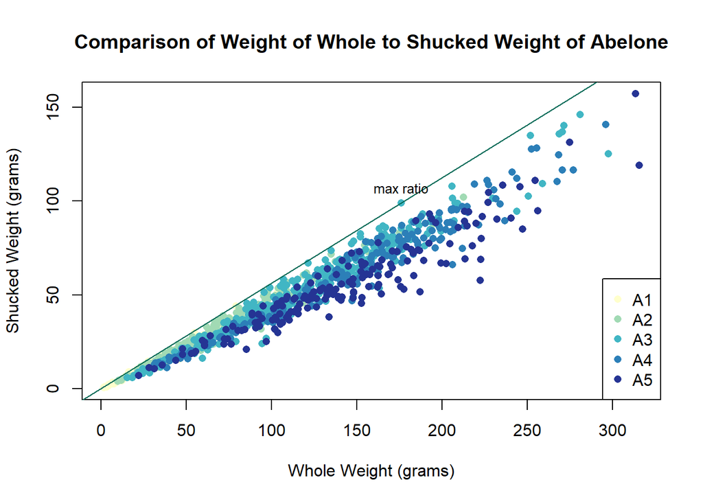

**Question (2 points): How does the variability in this plot differ from the plot in (a)? Compare the two displays. Keep in mind that SHUCK is a part of WHOLE. Consider the location of the different age classes.**

*Answer: Both plots have a rough positive correlation and similar shape. The plots start out with a tight correlation at the lower values but become more dispersed as the values become larger. The chart comparing abalone volume to whole weight is more dispersed in the higher values than the chart comparing whole weight to shucked weight. In the volume-whole weight comparison chart, regardless of age class, the abalone appear to be spread somewhat evenly across the chart. However, in the whole weight to shucked weight comparison chart, it seems as though whole weight continues to increase with age but shucked weight does not increase at the same pace. The older abalone appear to drop in their ratio of whole to shucked weight. Additionally, the maximum value of ratio between whole and shucked weight is in the A3 class, not in the A4 or A5 class.*

(3)(a) (2 points) Use “mydata” to create a multi-figured plot with histograms, boxplots and Q-Q plots of RATIO differentiated by sex. This can be done using *par(mfrow = c(3,3))* and base R or *grid.arrange()* and ggplot2. The first row would show the histograms, the second row the boxplots and the third row the Q-Q plots. Be sure these displays are legible.

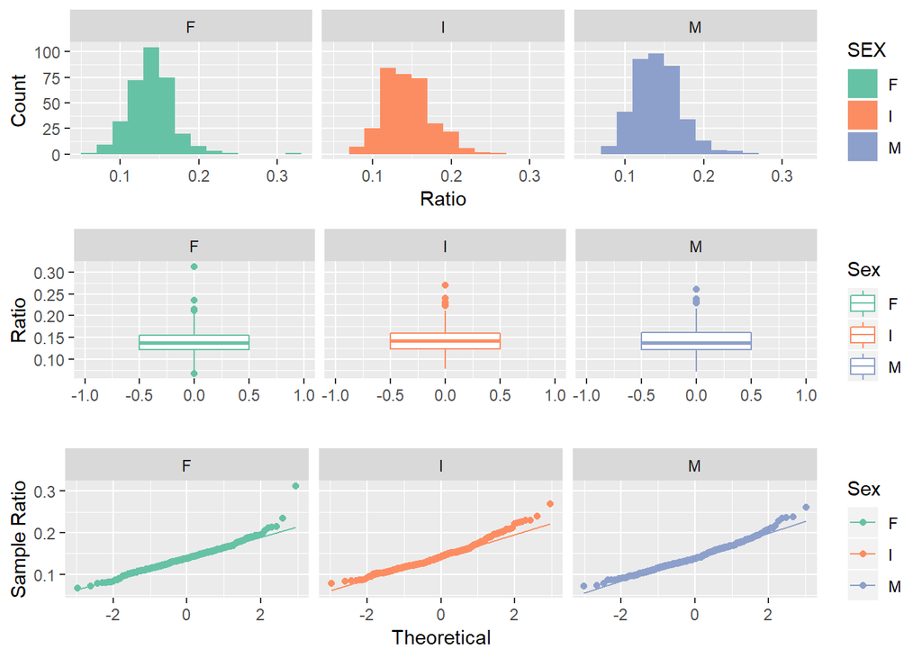

**Question (2 points): Compare the displays. How do the distributions compare to normality? Take into account the criteria discussed in the sync sessions to evaluate non-normality.**

(3)(b) (2 points) Use the boxplots to identify RATIO outliers (mild and extreme both) for each sex. Present the abalones with these outlying RATIO values along with their associated variables in “mydata” (Hint: display the observations by passing a data frame to the kable() function).

Mild Ratio Outliers Determined by Sex

|  | SEX | LENGTH | DIAM | HEIGHT | WHOLE | SHUCK | RINGS | CLASS | VOLUME | RATIO |
| --- | --- | --- | --- | --- | --- | --- | --- | --- | --- | --- |
| 746 | M | 13.440 | 10.815 | 1.680 | 130.25000 | 63.73125 | 10 | A3 | 244.194048 | 0.2609861 |
| 754 | M | 10.500 | 7.770 | 3.150 | 132.68750 | 61.13250 | 9 | A3 | 256.992750 | 0.2378764 |
| 803 | M | 10.710 | 8.610 | 3.255 | 160.31250 | 70.41375 | 9 | A3 | 300.153640 | 0.2345924 |
| 810 | M | 12.285 | 9.870 | 3.465 | 176.12500 | 99.00000 | 10 | A3 | 420.141472 | 0.2356349 |
| 852 | M | 11.550 | 8.820 | 3.360 | 167.56250 | 78.27187 | 10 | A3 | 342.286560 | 0.2286735 |
| 350 | F | 7.980 | 6.720 | 2.415 | 80.93750 | 40.37500 | 7 | A2 | 129.505824 | 0.3117620 |
| 379 | F | 15.330 | 11.970 | 3.465 | 252.06250 | 134.89812 | 10 | A3 | 635.827846 | 0.2121614 |
| 420 | F | 11.550 | 7.980 | 3.465 | 150.62500 | 68.55375 | 10 | A3 | 319.365585 | 0.2146560 |
| 421 | F | 13.125 | 10.290 | 2.310 | 142.00000 | 66.47062 | 9 | A3 | 311.979938 | 0.2130606 |
| 458 | F | 11.445 | 8.085 | 3.150 | 139.81250 | 68.49062 | 9 | A3 | 291.478399 | 0.2349767 |
| 586 | F | 12.180 | 9.450 | 4.935 | 133.87500 | 38.25000 | 14 | A5 | 568.023435 | 0.0673388 |
| 3 | I | 10.080 | 7.350 | 2.205 | 79.37500 | 44.00000 | 6 | A1 | 163.364040 | 0.2693371 |
| 37 | I | 4.305 | 3.255 | 0.945 | 6.18750 | 2.93750 | 3 | A1 | 13.242072 | 0.2218308 |
| 42 | I | 2.835 | 2.730 | 0.840 | 3.62500 | 1.56250 | 4 | A1 | 6.501222 | 0.2403394 |
| 58 | I | 6.720 | 4.305 | 1.680 | 22.62500 | 11.00000 | 5 | A1 | 48.601728 | 0.2263294 |
| 67 | I | 5.040 | 3.675 | 0.945 | 9.65625 | 3.93750 | 5 | A1 | 17.503290 | 0.2249577 |
| 89 | I | 3.360 | 2.310 | 0.525 | 2.43750 | 0.93750 | 4 | A1 | 4.074840 | 0.2300704 |
| 105 | I | 6.930 | 4.725 | 1.575 | 23.37500 | 11.81250 | 7 | A2 | 51.572194 | 0.2290478 |
| 200 | I | 9.135 | 6.300 | 2.520 | 74.56250 | 32.37500 | 8 | A2 | 145.027260 | 0.2232339 |

Extreme Ratio Outliers Determined by Sex

|  | SEX | LENGTH | DIAM | HEIGHT | WHOLE | SHUCK | RINGS | CLASS | VOLUME | RATIO |
| --- | --- | --- | --- | --- | --- | --- | --- | --- | --- | --- |
| 350 | F | 7.98 | 6.72 | 2.415 | 80.9375 | 40.375 | 7 | A2 | 129.5058 | 0.3117620 |
| 3 | I | 10.08 | 7.35 | 2.205 | 79.3750 | 44.000 | 6 | A1 | 163.3640 | 0.2693371 |

**Question (2 points): What are your observations regarding the results in (3)(b)?**

*Answer: There are quite a few mild outliers (19 to be exact). As we saw from the charts above, the plots are slightly skewed right so this is expected. There are also two extreme outliers. The female outlier was immediately apparent when viewing the small multiple charts created prior to the outlier calculations so that was not shocking. The one infant outlier was just barely beyond the threshold of what constitutes an extreme outlier (.269 vs a threshold of .2685) which is why it was not as noticeable as the female outlier. Overall, due to the skew, it is not surprising that there are so many mild outliers or that there is such a high proportion of mild outliers to extreme outliers because the distributions are neither normal or extremely skewed.*

(4)(a) (3 points) With “mydata,” display side-by-side boxplots for VOLUME and WHOLE, each differentiated by CLASS There should be five boxes for VOLUME and five for WHOLE. Also, display side-by-side scatterplots: VOLUME and WHOLE versus RINGS. Present these four figures in one graphic: the boxplots in one row and the scatterplots in a second row. Base R or ggplot2 may be used.

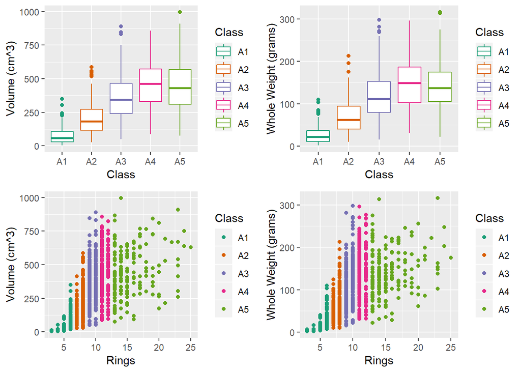

**Question (5 points) How well do you think these variables would perform as predictors of age? Explain.**

*Answer: There is a general positive trend between the number of rings and both the whole weight and volume variables. However, both variables have a wide range of variability for the A3, A4, and A5 classes. Even the A1 and A2 classes quickly disperse and the values on the lower end of the volume and whole weight ranges for those classes do not change by much, if at all. Therefore, both volume and whole would not perform well as predictors of abalone age, unless the prediction was am extremely rough estimate only being made for young (the A1 and A2 class) abalone.*

(5)(a) (2 points) Use *aggregate()* with “mydata” to compute the mean values of VOLUME, SHUCK and RATIO for each combination of SEX and CLASS. Then, using *matrix()*, create matrices of the mean values. Using the “dimnames” argument within *matrix()* or the *rownames()* and *colnames()* functions on the matrices, label the rows by SEX and columns by CLASS. Present the three matrices (Kabacoff Section 5.6.2, p. 110-111). The *kable()* function is useful for this purpose. You do not need to be concerned with the number of digits presented.

Mean Abalone Volume by Sex and Class

|  | A1 | A2 | A3 | A4 | A5 |
| --- | --- | --- | --- | --- | --- |
| F | 255.29938 | 276.8573 | 412.6079 | 498.0489 | 486.1525 |
| I | 66.51618 | 160.3200 | 270.7406 | 316.4129 | 318.6930 |
| M | 103.72320 | 245.3857 | 358.1181 | 442.6155 | 440.2074 |

Mean Abalone Shuck Weight by Sex and Class

[output not shown]

Mean Abalone Ratio (Shuck Weight to Volume) by Sex and Class

[output not shown]

(5)(b) (3 points) Present three graphs. Each graph should include three lines, one for each sex. The first should show mean RATIO versus CLASS; the second, mean VOLUME versus CLASS; the third, mean SHUCK versus CLASS. This may be done with the ‘base R’ *interaction.plot()* function or with ggplot2 using *grid.arrange()*.

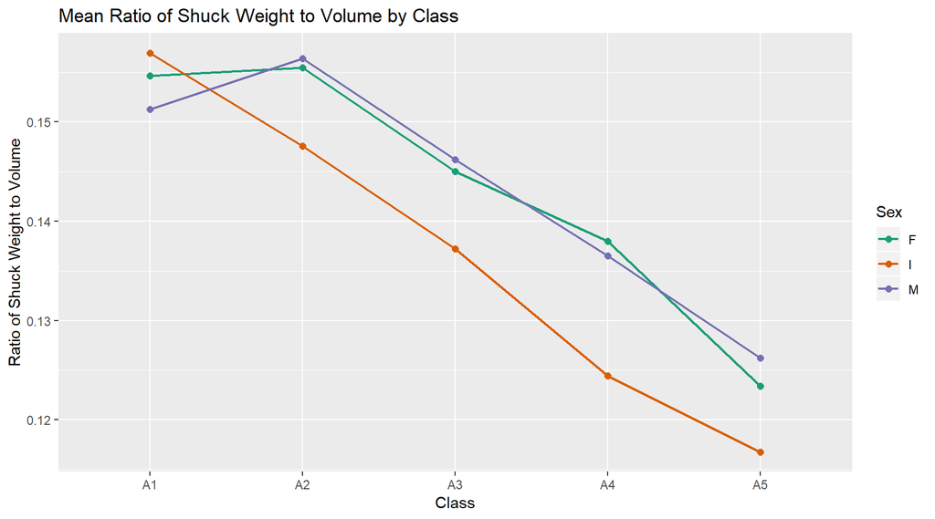

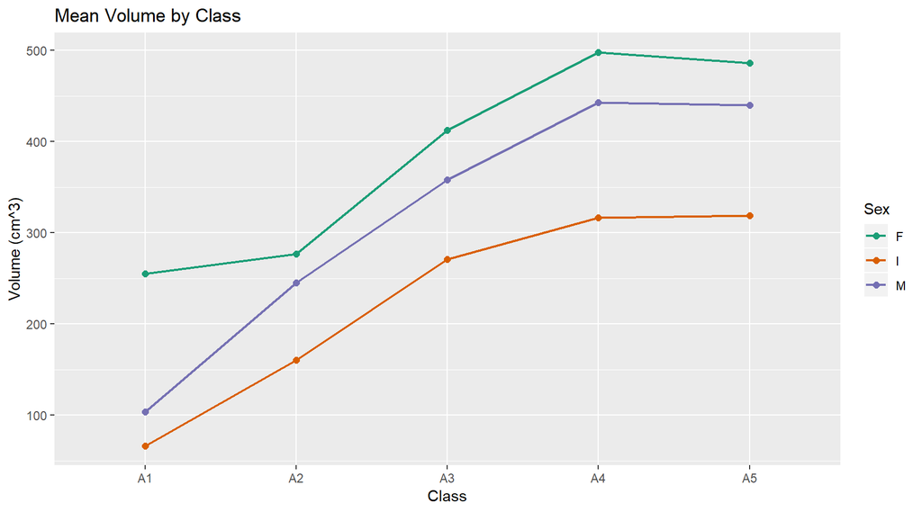

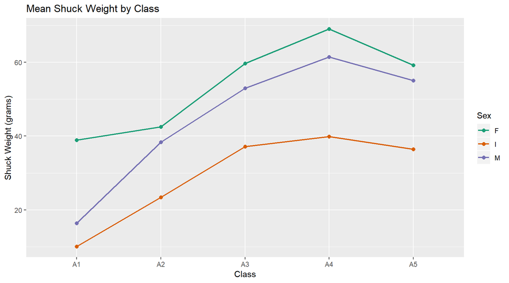

**Question (2 points): What questions do these plots raise? Consider aging and sex differences.**

*Answer: The first plot of shuck weight to volume presents additional evidence that as an abalone ages, the volume continues to increase but the shuck weight does not continue to increase at the same rate. It is interesting that A3 begins the decline of the volume to shuck weight ratio since we saw the A3 class have the highest ratio of whole weight to shucked weight. It is possibly because the shucked weight is not increasing as quickly as the volume in this class but the ratio still hasn’t dropped nearly as much as it does in the A4 or A5 class. The mean volume graph shows what we would have probably expected. As an abalone ages, the volume rather steadily increases. The most surprising fact comes from the last chart, where the A5 class actually decreases in mean weight. The A5 class contains a wide range of ages (14.5 to 26.5 based on the rings) so it’s possible that there is some noise in this class as well but the general trend of increasing then decreasing is one that definitely plays an impact on the ratio observed in the first chart. Overall, the general trend shows that shuck weight and volume increase at roughly the same pace in early abalone age but as volume continues to increase in older age, shuck weight experiences a slowdown in the rate of increase, ultimately leading to a reversal and a decrease in the weight.*

5(c) (3 points) Present four boxplots using *par(mfrow = c(2, 2)* or *grid.arrange()*. The first line should show VOLUME by RINGS for the infants and, separately, for the adult; factor levels “M” and “F,” combined. The second line should show WHOLE by RINGS for the infants and, separately, for the adults. Since the data are sparse beyond 15 rings, limit the displays to less than 16 rings. One way to accomplish this is to generate a new data set using subset() to select RINGS < 16. Use ylim = c(0, 1100) for VOLUME and ylim = c(0, 400) for WHOLE. If you wish to reorder the displays for presentation purposes or use ggplot2 go ahead.

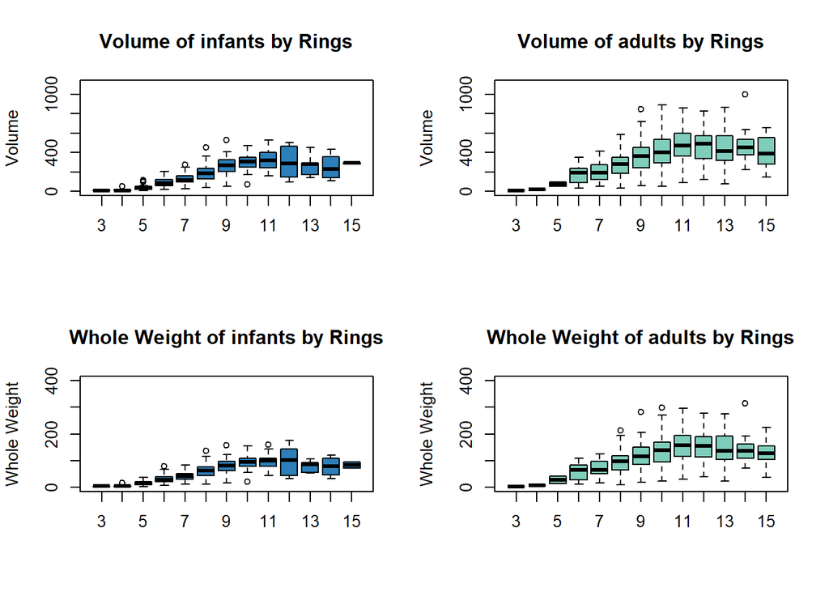

**Question (2 points): What do these displays suggest about abalone growth? Also, compare the infant and adult displays. What differences stand out?**

*Answer: The charts on the left side of the panel show that volume and whole weight increase until the point of 10 rings then it levels off for infants. The charts beyond 10 can be easily misinterpreted though because earlier evaluations of class by sex have shown that there are only a few infants in the upper classes (therefore only a few many-ringed abalone being classified as infants). The plots on the right side of panel show a general trend we would expect. Only a few abalone that have been classified as adults being listed as having low values of rings. Similar to infants, the whole weight and volume increases up until the point of 10 rings then it levels off for volume and actually decreases slightly for whole weight. The main noticeable difference between the two is the size of the interquartile range for adults compared to infants. Infants seem to have a much tighter distribution for each of the groupings of rings, while adults seem to be more dispersed with both volume and weight.*

**Conclusions**

Please respond to each of the following questions (10 points total):

**Question 1) (5 points) Based solely on these data, what are plausible statistical reasons that explain the failure of the original study? Consider to what extent physical measurements may be used for age prediction.**

*Answer: It seems that the methods to collect data or analyze the results of the abalones collected may have played a factor in the failure of the study. From the high level sample statistics, it was immidiately apparant that there was a much higher proportion of males than females. Whether this was misclassification or a problem with the sampling method is unknown. Additional misclassification of the data may have played a factor as well. If rings (and class by proxy) are to be the most trusted measure of age, then it wouldn’t warrant so many male and female abalone being included in the A1 and A2 classes, unless only some abalone could be classified. The A4 and A5 also had some abalone that were classified as infant. To speculate on the cause, it’s possible that even some older abalone were not easily classified. That could have lead to additional confusion but a fourth category should have been added in the case where rings were counted (so the abelone is a confirmed as an adult) but no classification of sex could be made (potentially called unclassified). The sparse nature in the abelones with many rings also could have lead to some potentially confusing results where the data shows abelone with many rings actually have less weight and lower volume. Finally, the fact that the class variable categorizing the ages of the abalone was not uniform makes it difficult to draw conclusions when one class (A3) has almost double some of the other classes. These problems in classification make it difficult to trust any of the conculsions drawn from the data in the study.*

**Question 2) (3 points) Do not refer to the abalone data or study. If you were presented with an overall histogram and summary statistics from a sample of some population or phenomenon and no other information, what questions might you ask before accepting them as representative of the sampled population or phenomenon?**

*Answer: I would start by asking how large the population was, to determine how large of a sample size had been taken from the population. I would also ask about the methods used to draw the samples (whether they were random or whether there was a chance for bias introduced by the researcher gathering the sample). I would also ask if there were any statistics or classifications known about the population the sample was drawn from (distribution, mean, standard deviation).*

**Question 3) (2 points) Do not refer to the abalone data or study. What do you see as difficulties analyzing data derived from observational studies? Can causality be determined? What might be learned from such studies?**

*Answer: In general, analyzing observational study data is difficult when the methods for collection or categorization of data are unknown. Using this kind of data means that you are at the discretion of the researcher to give you good data and make sure that the data was not manipulated incorrectly or that there was no bias introduced. Determining causality from a single study is also extremely difficult. It is easy to use study data to draw correlations between variables but as we have seen in this course many times, correlation does not imply causation. To get a better understanding of causality, a controlled experiment may be a better indicator of what is contributing to the linkage of two variables. General exploratory analysis is still helpful in observational studies though. Such analysis can give researchers an understanding of what is contained in the data that was collected and if a researcher should conduct further studies or experiments on specific correlations or observations that might warrant additional analysis.*